# Tema 15 - Métodos basados en árboles

Universidad de Alicante, Curso 2021/22

## Estratificación para asociaciones no lineales

- Ejemplo: relación no lineal en los datos de viviendas de Boston

```r
Boston <- read_csv("https://www.dropbox.com/s/h218wwp18j0j8d7/BostonHousing1.csv?dl=1")

Boston %>%  ggplot(aes(lstat, medv)) + geom_point() +
  geom_smooth(method = lm, se = FALSE,
    formula = y ~ (x>25) + (x<=25 & x>=15) + (x<15) -1
  )
```

[output not shown]

```r
Boston %>%  ggplot(aes(lstat, medv)) + geom_point() +
  geom_smooth(method = lm, se = FALSE,
  formula = y ~ (x>25) + (x<=25 & x>=15) + (x<15 & x>=5) + (x<5) -1
  )
```

[output not shown]

- Cuantos más particiones, mejor ajuste
- PERO ¿dónde dividimos?, ¿cuántas particiones?

## Árboles de decisión

- Un árbol de decisión es un diagrama de flujo con reglas para segmentar el espacio de regresores en regiones más simples y clasificar observaciones

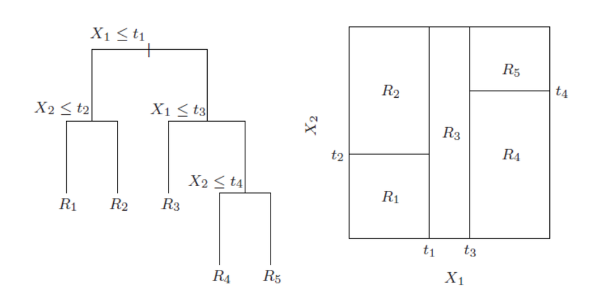

## Árboles de Regresión

- ¿Cómo construimos estos árboles para una variable cuantitativa?
  1. Dividir el espacio de predicción, \(\small x_1, x_2, \dots, x_p\) en regiones \(\small J\) distintas y no superpuestas, \(\small R_1, R_2, \dots, R_J\) (cada vez más homogéneas/“puras”)
  2. Cada observación que caiga en la región \(\small R_j\) tiene el mismo valor predicho: la media de \(\small y\) para las observaciones de entrenamiento en \(\small R_j\)
- ¿Cómo determinar las regiones apropiadas \(\small R_1, R_2, \dots, R_J\)? Es computacionalmente inviable considerar todas las particiones en \(\small J\) regiones.
- Alternativas heurísticas: un algoritmo “voraz” elige una opción localmente óptima en cada paso con la esperanza de llegar a una solución general óptima
  - en lugar de elegir la mejor partición para un paso futuro

## Partición binaria recursiva

1. En la parte alta, todas las observaciones pertenecen a una sola región
2. Se divide sucesivamente cada región en dos ramas: \(\small R_1(j,s) = \{X|X_j < s\}\) y \(\small R_2(j,s) = \{X|X_j \geq s\}\)
   - En cada nodo, se consideran *todos* los regresores \(\small X_j\) y *todos* los umbrales \(s\)
   - Se calcula \(\small SCR_{j,s} = \sum_{i\in R_1(j,s)}(y_i-\widehat{y}_{R_1})^2 + \sum_{i\in R_2(j,s)}(y_i-\widehat{y}_{R_2})^2\)
   - SOLO una partición en cada iteración: se elige \(\small j\) y \(\small s\) con menor \(\small SCR_{j,s}\)
3. Repetimos el proceso particionando cada región de la iteración anterior
4. Se continua hasta que se cumpla un criterio de parada; p.e., ninguna región contiene más de \(5\) observaciones

## Podar un árbol (*pruning*)

- Evitar árboles demasiados complejos (“overfitting”)
- Hacer crecer un árbol “grande” con \(\small T_0\) nodos terminales y **podarlo** para quedarnos con un sub-árbol con \(\small T\) nodos terminales \[\small min \sum_{m=1}^T \sum_{i \in R_m} (y_i-\widehat{y}_{R_m})^2 + \alpha |T| \]
  - donde \(\small R_m\) es la región de \(\small m\)-nodo terminal
- \(\small \alpha\) es el hiperparametro de **coste de complejidad** de la poda, elegido por validación cruzada

## Árboles de clasificación

- Para un árbol de clasificación, se predice que cada observación pertenece a la clase más común en la región a la que pertenece en entrenamiento
- También se pueden obtener la proporción de una clase \(\small k\) dentro de una región particular \(\small m\) de nodos terminales: \(\small \widehat{p}_{mk}\)
- La métrica usada para hacer crecer los árboles NO puede ser SCR
1. Índice de Gini: medida de la varianza entre clases \(\small G=\sum_{k=1}^{K}\widehat{p}_{mk}(1-\widehat{p}_{mk})\)
2. Entropía (cruzada) \(\small D=\sum_{k=1}^{K}\widehat{p}_{mk}log(\widehat{p}_{mk})\)
- Ambos son medidas de “pureza” del nodo: un valor pequeño indica que la región contiene en su mayoría observaciones de una sola clase.

## Algoritmos para árboles e hiperparámetros

- Motores para árboles: `rpart` (defecto), `spark` y `C5.0` (solo clasificación)
- Depende de varios hiperparámetros elegidos por *tuning*
  - `min_n`: mínimo número de observaciones en un nodo parar dividirse más
  - `tree_depth`: máx. número de niveles de profundidad del árbol (no `C5.0`)
  - `cost_complexity`: coste de complejidad (sólo `rpart`)

```r
censo_modelo_arbol  <- set_engine("rpart") %>% decision_tree(mode = "classification",
                                     cost_complexity = .01)
```

- Podemos visualizar un modelo árbol estimado con la biblioteca `rpart.plot`

```r
arbol <- censo_flujo_arbol_est %>% extract_fit_parsnip()
rpart.plot(arbol$fit)
```

[output not shown]

## Comentarios

- Predicción: media o clase mayoritaria de las observaciones de entrenamiento en el nodo que corresponde a una observación nueva
- Importancia de las variables: reducción total de la SCR o Gini debida a las particiones de una variable
  - variables usadas en nodos iniciales o mas veces son más importantes
- Ventajas:
  - ajusta (no paramétricamente) relaciones no lineales/complejeas
  - fáciles de explicar (más que la regresión lineal) y visualizar
  - no requieren dummies
- Desventajas: *overfit* (no robustos a cambios en los datos) y bajo poder de predicción

## *Bagging*

- Agregación de Bootstrap (*bagging*): procedimiento general para reducir la varianza, promediando \(\small \{x_i\}_{i=1}^n iid \sim (\mu, \sigma^2) \Rightarrow \bar{x} \sim (\mu, \sigma^2/n)\)
- Podemos tomar \(B\) re-muestras del **único** conjunto de entrenamiento
- En lugar de un único árbol complejo, se combinan muchos árboles diversos que pueden reflejar patrones sutiles
- La variación muestral en las condiciones de “entrenamiento” se genera mediante “bootstrap”

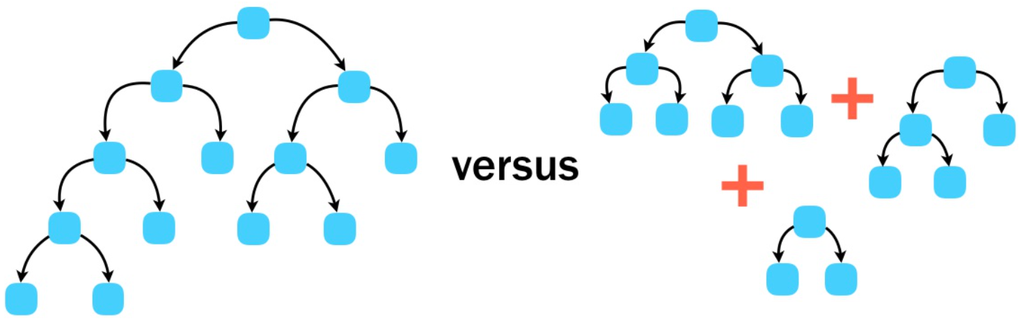

## “Random forest”

- Es un algoritmo específico de agregación de árboles que introduce aleatorización para **eliminar correlación** entre los árboles.
  - Se construyen varios árboles en muestras de entrenamiento de bootstrap
  - En cada partición de un árbol, se seleccionan aleatoriamente \(\small m \approx \sqrt{k}\) regresores del total
  - Se mitiga la influencia de regresores fuertes, permitiendo una mayor diversidad en los árboles agregados
- Mejor predicción a expensas de la interpretación \(\Rightarrow\) medidas de importancia variable: reducción promedio en SCR / Gini para un regresor en los \(\small B\) árboles
- La importancia tiene un papel análogo al de los p-valores (sin una inferencia estadística formal), para ayudar a generar hipótesis.

## Algoritmos para RF e hiperparámetros

- Motores principales para RF en R: `ranger`, `randomForest` y `spark`
- Depende de `trees`, números de árboles, a considerar en la agregación (no genera “overfitting”) y de dos hiperparámetros
  - `mtry`: número de variables a considerar en cada partición
  - `min_n`: igual que en árboles

```r
RailTrail_modelo_RF  <- rand_forest(mode = "regression",          # classification
                                       mtry = 3, trees = 100) %>%
                          set_engine("ranger", importance = "impurity")

RailTrail_flujo_RF_est_fit <- extract_fit_parsnip(RailTrail_flujo_RF_est)$fit
RailTrail_flujo_RF_est_fit$variable.importance

library(vip)
extract_fit_parsnip(RailTrail_flujo_RF_est) %>% vip()
```

[output not shown]